# Risk Factor Analysis

## Outcome Variable

**Outcome Variable:** haz

## Predictor Variables

**Intervention Variable:** perdiar24

**Adjustment Set:**

unadjusted

## Stratifying Variables

The analysis was stratified on these variable(s):

- agecat
- studyid
- country

## Data Summary

| agecat | studyid | country | perdiar24 | n_cell | n |
| --- | --- | --- | --- | --- | --- |
| Birth | CMIN | BANGLADESH | 0% | 12 | 26 |
| Birth | CMIN | BANGLADESH | (0%, 5%] | 4 | 26 |
| Birth | CMIN | BANGLADESH | >5% | 10 | 26 |
| Birth | CONTENT | PERU | 0% | 0 | 2 |
| Birth | CONTENT | PERU | (0%, 5%] | 1 | 2 |
| Birth | CONTENT | PERU | >5% | 1 | 2 |
| Birth | EE | PAKISTAN | 0% | 161 | 240 |
| Birth | EE | PAKISTAN | (0%, 5%] | 79 | 240 |
| Birth | EE | PAKISTAN | >5% | 0 | 240 |
| Birth | JiVitA-4 | BANGLADESH | 0% | 76 | 2823 |
| Birth | JiVitA-4 | BANGLADESH | (0%, 5%] | 2449 | 2823 |
| Birth | JiVitA-4 | BANGLADESH | >5% | 298 | 2823 |
| Birth | MAL-ED | BANGLADESH | 0% | 18 | 231 |
| Birth | MAL-ED | BANGLADESH | (0%, 5%] | 131 | 231 |
| Birth | MAL-ED | BANGLADESH | >5% | 82 | 231 |
| Birth | MAL-ED | BRAZIL | 0% | 34 | 65 |
| Birth | MAL-ED | BRAZIL | (0%, 5%] | 29 | 65 |
| Birth | MAL-ED | BRAZIL | >5% | 2 | 65 |
| Birth | MAL-ED | INDIA | 0% | 5 | 47 |
| Birth | MAL-ED | INDIA | (0%, 5%] | 33 | 47 |
| Birth | MAL-ED | INDIA | >5% | 9 | 47 |
| Birth | MAL-ED | NEPAL | 0% | 2 | 27 |
| Birth | MAL-ED | NEPAL | (0%, 5%] | 19 | 27 |
| Birth | MAL-ED | NEPAL | >5% | 6 | 27 |
| Birth | MAL-ED | PERU | 0% | 21 | 233 |
| Birth | MAL-ED | PERU | (0%, 5%] | 89 | 233 |
| Birth | MAL-ED | PERU | >5% | 123 | 233 |
| Birth | MAL-ED | SOUTH AFRICA | 0% | 42 | 113 |
| Birth | MAL-ED | SOUTH AFRICA | (0%, 5%] | 70 | 113 |
| Birth | MAL-ED | SOUTH AFRICA | >5% | 1 | 113 |

[output cut: 102 more lines]

The following strata were considered:

- agecat: 24 months, studyid: CMIN, country: BANGLADESH
- agecat: 24 months, studyid: CONTENT, country: PERU
- agecat: 24 months, studyid: EE, country: PAKISTAN
- agecat: 24 months, studyid: JiVitA-4, country: BANGLADESH
- agecat: 24 months, studyid: MAL-ED, country: BANGLADESH
- agecat: 24 months, studyid: MAL-ED, country: BRAZIL
- agecat: 24 months, studyid: MAL-ED, country: INDIA
- agecat: 24 months, studyid: MAL-ED, country: NEPAL
- agecat: 24 months, studyid: MAL-ED, country: PERU
- agecat: 24 months, studyid: MAL-ED, country: SOUTH AFRICA
- agecat: 24 months, studyid: MAL-ED, country: TANZANIA, UNITED REPUBLIC OF
- agecat: 24 months, studyid: NIH-Birth, country: BANGLADESH
- agecat: 24 months, studyid: NIH-Crypto, country: BANGLADESH
- agecat: 24 months, studyid: PROVIDE, country: BANGLADESH
- agecat: 6 months, studyid: CMIN, country: BANGLADESH
- agecat: 6 months, studyid: CONTENT, country: PERU
- agecat: 6 months, studyid: EE, country: PAKISTAN
- agecat: 6 months, studyid: Guatemala BSC, country: GUATEMALA
- agecat: 6 months, studyid: JiVitA-4, country: BANGLADESH
- agecat: 6 months, studyid: MAL-ED, country: BANGLADESH
- agecat: 6 months, studyid: MAL-ED, country: BRAZIL
- agecat: 6 months, studyid: MAL-ED, country: INDIA
- agecat: 6 months, studyid: MAL-ED, country: NEPAL
- agecat: 6 months, studyid: MAL-ED, country: PERU
- agecat: 6 months, studyid: MAL-ED, country: SOUTH AFRICA
- agecat: 6 months, studyid: MAL-ED, country: TANZANIA, UNITED REPUBLIC OF
- agecat: 6 months, studyid: NIH-Birth, country: BANGLADESH
- agecat: 6 months, studyid: NIH-Crypto, country: BANGLADESH
- agecat: 6 months, studyid: PROVIDE, country: BANGLADESH
- agecat: 6 months, studyid: SAS-FoodSuppl, country: INDIA
- agecat: Birth, studyid: CMIN, country: BANGLADESH
- agecat: Birth, studyid: CONTENT, country: PERU
- agecat: Birth, studyid: EE, country: PAKISTAN
- agecat: Birth, studyid: JiVitA-4, country: BANGLADESH
- agecat: Birth, studyid: MAL-ED, country: BANGLADESH
- agecat: Birth, studyid: MAL-ED, country: BRAZIL
- agecat: Birth, studyid: MAL-ED, country: INDIA
- agecat: Birth, studyid: MAL-ED, country: NEPAL
- agecat: Birth, studyid: MAL-ED, country: PERU
- agecat: Birth, studyid: MAL-ED, country: SOUTH AFRICA
- agecat: Birth, studyid: MAL-ED, country: TANZANIA, UNITED REPUBLIC OF
- agecat: Birth, studyid: NIH-Birth, country: BANGLADESH
- agecat: Birth, studyid: NIH-Crypto, country: BANGLADESH
- agecat: Birth, studyid: PROVIDE, country: BANGLADESH

### Dropped Strata

Some strata were dropped due to rare outcomes:

- agecat: Birth, studyid: CMIN, country: BANGLADESH
- agecat: Birth, studyid: CONTENT, country: PERU
- agecat: Birth, studyid: EE, country: PAKISTAN
- agecat: Birth, studyid: MAL-ED, country: BRAZIL
- agecat: Birth, studyid: MAL-ED, country: NEPAL
- agecat: Birth, studyid: MAL-ED, country: SOUTH AFRICA
- agecat: 6 months, studyid: CMIN, country: BANGLADESH
- agecat: 6 months, studyid: EE, country: PAKISTAN
- agecat: 6 months, studyid: MAL-ED, country: BRAZIL
- agecat: 6 months, studyid: MAL-ED, country: INDIA
- agecat: 6 months, studyid: MAL-ED, country: SOUTH AFRICA
- agecat: 24 months, studyid: CMIN, country: BANGLADESH
- agecat: 24 months, studyid: CONTENT, country: PERU
- agecat: 24 months, studyid: EE, country: PAKISTAN
- agecat: 24 months, studyid: MAL-ED, country: BRAZIL
- agecat: 24 months, studyid: MAL-ED, country: INDIA
- agecat: 24 months, studyid: MAL-ED, country: PERU
- agecat: 24 months, studyid: MAL-ED, country: SOUTH AFRICA

## Methods Detail

We’re interested in the causal parameters $E[Y_a]$ for all values of $a \in \mathcal{A}$. These parameters represent the mean outcome if, possibly contrary to fact, we intervened to set all units to have $A=a$. Under the randomization and positivity assumptions, these are identified by the statistical parameters $\psi_a=E_W[E_{Y|A,W}(Y|A=a,W)]$. In addition, we’re interested in the mean of $Y$, $E[Y]$ under no intervention (the observed mean). We will estimate these parameters by using SuperLearner to fit the relevant likelihood factors – $E_{Y|A,W}(Y|A=a,W)$ and $p(A=a|W)$, and then updating our likelihood fit using a joint TMLE.

For unadjusted analyses ($W=\{\}$), initial likelihoods were estimated using Lrnr_glm to estimate the simple $E(Y|A)$ and Lrnr_mean to estimate $p(A)$. For adjusted analyses, a small library containing Lrnr_glmnet, Lrnr_xgboost, and Lrnr_mean was used.

Having estimated these parameters, we will then use the delta method to estimate relative risks and attributable risks relative to a prespecified baseline level of $A$.

# Results Detail

## Results Plots

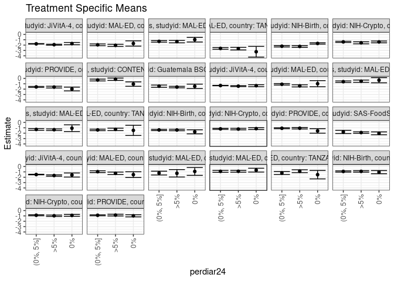

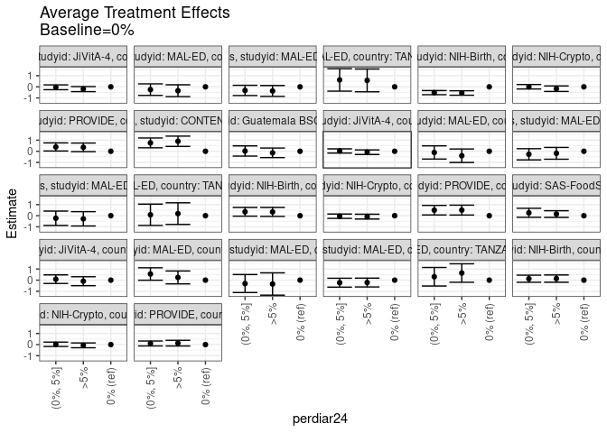

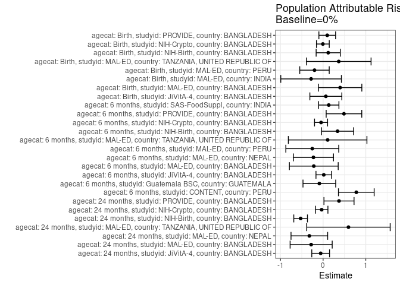

## Results Table

### Parameter: TSM

| agecat | studyid | country | intervention_level | baseline_level | estimate | ci_lower | ci_upper |
| --- | --- | --- | --- | --- | --- | --- | --- |
| Birth | JiVitA-4 | BANGLADESH | 0% | NA | -1.5877632 | -1.9686026 | -1.2069238 |
| Birth | JiVitA-4 | BANGLADESH | (0%, 5%] | NA | -1.5019028 | -1.5548653 | -1.4489403 |
| Birth | JiVitA-4 | BANGLADESH | >5% | NA | -1.6826174 | -1.8112514 | -1.5539835 |
| Birth | MAL-ED | BANGLADESH | 0% | NA | -1.5172222 | -2.0513134 | -0.9831311 |
| Birth | MAL-ED | BANGLADESH | (0%, 5%] | NA | -0.9657252 | -1.1345977 | -0.7968527 |
| Birth | MAL-ED | BANGLADESH | >5% | NA | -1.2739024 | -1.5027804 | -1.0450245 |
| Birth | MAL-ED | INDIA | 0% | NA | -0.9220000 | -1.6509223 | -0.1930777 |
| Birth | MAL-ED | INDIA | (0%, 5%] | NA | -1.2281818 | -1.5833498 | -0.8730139 |
| Birth | MAL-ED | INDIA | >5% | NA | -1.2700000 | -1.9601079 | -0.5798921 |
| Birth | MAL-ED | PERU | 0% | NA | -0.6809524 | -1.0395711 | -0.3223337 |
| Birth | MAL-ED | PERU | (0%, 5%] | NA | -0.9094382 | -1.0884347 | -0.7304417 |
| Birth | MAL-ED | PERU | >5% | NA | -0.8979675 | -1.0671488 | -0.7287862 |
| Birth | MAL-ED | TANZANIA, UNITED REPUBLIC OF | 0% | NA | -1.5222222 | -2.3091001 | -0.7353443 |
| Birth | MAL-ED | TANZANIA, UNITED REPUBLIC OF | (0%, 5%] | NA | -1.2164706 | -1.4939186 | -0.9390226 |
| Birth | MAL-ED | TANZANIA, UNITED REPUBLIC OF | >5% | NA | -0.8822581 | -1.1471959 | -0.6173203 |
| Birth | NIH-Birth | BANGLADESH | 0% | NA | -1.0513725 | -1.3462846 | -0.7564605 |
| Birth | NIH-Birth | BANGLADESH | (0%, 5%] | NA | -0.9249710 | -1.0473535 | -0.8025885 |
| Birth | NIH-Birth | BANGLADESH | >5% | NA | -0.9127512 | -1.0542792 | -0.7712232 |
| Birth | NIH-Crypto | BANGLADESH | 0% | NA | -0.9038411 | -1.0757728 | -0.7319093 |
| Birth | NIH-Crypto | BANGLADESH | (0%, 5%] | NA | -0.8786010 | -0.9755415 | -0.7816606 |
| Birth | NIH-Crypto | BANGLADESH | >5% | NA | -0.9750256 | -1.1063730 | -0.8436783 |
| Birth | PROVIDE | BANGLADESH | 0% | NA | -0.9823636 | -1.1851702 | -0.7795571 |
| Birth | PROVIDE | BANGLADESH | (0%, 5%] | NA | -0.8845260 | -0.9766933 | -0.7923587 |
| Birth | PROVIDE | BANGLADESH | >5% | NA | -0.8522293 | -1.0082634 | -0.6961952 |
| 6 months | CONTENT | PERU | 0% | NA | -1.0567500 | -1.4658384 | -0.6476616 |
| 6 months | CONTENT | PERU | (0%, 5%] | NA | -0.3029472 | -0.4697708 | -0.1361235 |
| 6 months | CONTENT | PERU | >5% | NA | -0.1570746 | -0.3744579 | 0.0603086 |
| 6 months | Guatemala BSC | GUATEMALA | 0% | NA | -1.4736782 | -1.8824548 | -1.0649015 |
| 6 months | Guatemala BSC | GUATEMALA | (0%, 5%] | NA | -1.4497381 | -1.6578705 | -1.2416057 |
| 6 months | Guatemala BSC | GUATEMALA | >5% | NA | -1.6139500 | -1.7499439 | -1.4779561 |
| 6 months | JiVitA-4 | BANGLADESH | 0% | NA | -1.3605769 | -1.5461726 | -1.1749812 |
| 6 months | JiVitA-4 | BANGLADESH | (0%, 5%] | NA | -1.3317710 | -1.3726108 | -1.2909312 |
| 6 months | JiVitA-4 | BANGLADESH | >5% | NA | -1.4436877 | -1.5315061 | -1.3558694 |
| 6 months | MAL-ED | BANGLADESH | 0% | NA | -0.9866667 | -1.5612360 | -0.4120973 |
| 6 months | MAL-ED | BANGLADESH | (0%, 5%] | NA | -1.0936385 | -1.2371707 | -0.9501063 |
| 6 months | MAL-ED | BANGLADESH | >5% | NA | -1.3891039 | -1.5904471 | -1.1877608 |
| 6 months | MAL-ED | NEPAL | 0% | NA | -0.3346429 | -0.8209957 | 0.1517099 |
| 6 months | MAL-ED | NEPAL | (0%, 5%] | NA | -0.6071096 | -0.7434031 | -0.4708160 |
| 6 months | MAL-ED | NEPAL | >5% | NA | -0.5193882 | -0.7294856 | -0.3092908 |
| 6 months | MAL-ED | PERU | 0% | NA | -1.0700000 | -1.6970711 | -0.4429289 |
| 6 months | MAL-ED | PERU | (0%, 5%] | NA | -1.3015443 | -1.4624676 | -1.1406211 |
| 6 months | MAL-ED | PERU | >5% | NA | -1.3503344 | -1.4983707 | -1.2022981 |
| 6 months | MAL-ED | TANZANIA, UNITED REPUBLIC OF | 0% | NA | -1.4750000 | -2.4233687 | -0.5266313 |
| 6 months | MAL-ED | TANZANIA, UNITED REPUBLIC OF | (0%, 5%] | NA | -1.3915631 | -1.5359143 | -1.2472119 |
| 6 months | MAL-ED | TANZANIA, UNITED REPUBLIC OF | >5% | NA | -1.2868579 | -1.5070055 | -1.0667103 |
| 6 months | NIH-Birth | BANGLADESH | 0% | NA | -1.7460000 | -2.1223087 | -1.3696913 |
| 6 months | NIH-Birth | BANGLADESH | (0%, 5%] | NA | -1.3942232 | -1.5087410 | -1.2797054 |
| 6 months | NIH-Birth | BANGLADESH | >5% | NA | -1.4040027 | -1.5508165 | -1.2571890 |
| 6 months | NIH-Crypto | BANGLADESH | 0% | NA | -1.1508209 | -1.3220068 | -0.9796350 |
| 6 months | NIH-Crypto | BANGLADESH | (0%, 5%] | NA | -1.1976036 | -1.2948985 | -1.1003088 |
| 6 months | NIH-Crypto | BANGLADESH | >5% | NA | -1.2336923 | -1.3662930 | -1.1010917 |
| 6 months | PROVIDE | BANGLADESH | 0% | NA | -1.5808333 | -2.0021611 | -1.1595056 |
| 6 months | PROVIDE | BANGLADESH | (0%, 5%] | NA | -1.0841483 | -1.1720302 | -0.9962664 |
| 6 months | PROVIDE | BANGLADESH | >5% | NA | -1.0764754 | -1.2186655 | -0.9342853 |
| 6 months | SAS-FoodSuppl | INDIA | 0% | NA | -2.0310959 | -2.2985455 | -1.7636463 |
| 6 months | SAS-FoodSuppl | INDIA | (0%, 5%] | NA | -1.7695652 | -2.0730457 | -1.4660847 |
| 6 months | SAS-FoodSuppl | INDIA | >5% | NA | -1.8844061 | -2.0207523 | -1.7480600 |
| 24 months | JiVitA-4 | BANGLADESH | 0% | NA | -1.7235758 | -1.9359666 | -1.5111850 |
| 24 months | JiVitA-4 | BANGLADESH | (0%, 5%] | NA | -1.7654079 | -1.8029320 | -1.7278839 |
| 24 months | JiVitA-4 | BANGLADESH | >5% | NA | -1.9270183 | -2.0181196 | -1.8359169 |
| 24 months | MAL-ED | BANGLADESH | 0% | NA | -1.6983333 | -2.1891875 | -1.2074792 |
| 24 months | MAL-ED | BANGLADESH | (0%, 5%] | NA | -1.9507308 | -2.1166572 | -1.7848043 |
| 24 months | MAL-ED | BANGLADESH | >5% | NA | -2.0478289 | -2.2529623 | -1.8426955 |
| 24 months | MAL-ED | NEPAL | 0% | NA | -0.9850000 | -1.4214027 | -0.5485973 |
| 24 months | MAL-ED | NEPAL | (0%, 5%] | NA | -1.3090000 | -1.4569681 | -1.1610319 |
| 24 months | MAL-ED | NEPAL | >5% | NA | -1.3559211 | -1.5761279 | -1.1357142 |
| 24 months | MAL-ED | TANZANIA, UNITED REPUBLIC OF | 0% | NA | -3.2400000 | -4.2371443 | -2.2428557 |
| 24 months | MAL-ED | TANZANIA, UNITED REPUBLIC OF | (0%, 5%] | NA | -2.6175962 | -2.7782509 | -2.4569414 |
| 24 months | MAL-ED | TANZANIA, UNITED REPUBLIC OF | >5% | NA | -2.6608654 | -2.9071887 | -2.4145421 |
| 24 months | NIH-Birth | BANGLADESH | 0% | NA | -1.6920000 | -1.8179481 | -1.5660519 |
| 24 months | NIH-Birth | BANGLADESH | (0%, 5%] | NA | -2.2130914 | -2.3480900 | -2.0780928 |
| 24 months | NIH-Birth | BANGLADESH | >5% | NA | -2.2487126 | -2.4051224 | -2.0923029 |
| 24 months | NIH-Crypto | BANGLADESH | 0% | NA | -1.4076423 | -1.5742251 | -1.2410595 |
| 24 months | NIH-Crypto | BANGLADESH | (0%, 5%] | NA | -1.4012681 | -1.5135226 | -1.2890137 |
| 24 months | NIH-Crypto | BANGLADESH | >5% | NA | -1.5732174 | -1.7595245 | -1.3869103 |
| 24 months | PROVIDE | BANGLADESH | 0% | NA | -1.9750000 | -2.3266294 | -1.6233706 |
| 24 months | PROVIDE | BANGLADESH | (0%, 5%] | NA | -1.5859747 | -1.6839331 | -1.4880162 |
| 24 months | PROVIDE | BANGLADESH | >5% | NA | -1.6204885 | -1.7821075 | -1.4588695 |

### Parameter: E(Y)

| agecat | studyid | country | intervention_level | baseline_level | estimate | ci_lower | ci_upper |
| --- | --- | --- | --- | --- | --- | --- | --- |
| Birth | JiVitA-4 | BANGLADESH | NA | NA | -1.5232908 | -1.5723277 | -1.4742539 |
| Birth | MAL-ED | BANGLADESH | NA | NA | -1.1180952 | -1.2525408 | -0.9836496 |
| Birth | MAL-ED | INDIA | NA | NA | -1.2036170 | -1.4976814 | -0.9095527 |
| Birth | MAL-ED | PERU | NA | NA | -0.8827897 | -1.0001058 | -0.7654736 |
| Birth | MAL-ED | TANZANIA, UNITED REPUBLIC OF | NA | NA | -1.1556000 | -1.3655361 | -0.9456639 |
| Birth | NIH-Birth | BANGLADESH | NA | NA | -0.9314050 | -1.0202164 | -0.8425936 |
| Birth | NIH-Crypto | BANGLADESH | NA | NA | -0.9094945 | -0.9809370 | -0.8380521 |
| Birth | PROVIDE | BANGLADESH | NA | NA | -0.8851020 | -0.9601332 | -0.8100709 |
| 6 months | CONTENT | PERU | NA | NA | -0.2785256 | -0.4098735 | -0.1471776 |
| 6 months | Guatemala BSC | GUATEMALA | NA | NA | -1.5619008 | -1.6727702 | -1.4510313 |
| 6 months | JiVitA-4 | BANGLADESH | NA | NA | -1.3447940 | -1.3820261 | -1.3075620 |
| 6 months | MAL-ED | BANGLADESH | NA | NA | -1.2049931 | -1.3222136 | -1.0877726 |
| 6 months | MAL-ED | NEPAL | NA | NA | -0.5615819 | -0.6741832 | -0.4489807 |
| 6 months | MAL-ED | PERU | NA | NA | -1.3236661 | -1.4316775 | -1.2156546 |
| 6 months | MAL-ED | TANZANIA, UNITED REPUBLIC OF | NA | NA | -1.3687449 | -1.4907629 | -1.2467270 |
| 6 months | NIH-Birth | BANGLADESH | NA | NA | -1.4073821 | -1.4960598 | -1.3187043 |
| 6 months | NIH-Crypto | BANGLADESH | NA | NA | -1.1986783 | -1.2700937 | -1.1272630 |
| 6 months | PROVIDE | BANGLADESH | NA | NA | -1.0916915 | -1.1661176 | -1.0172654 |
| 6 months | SAS-FoodSuppl | INDIA | NA | NA | -1.8986842 | -2.0118892 | -1.7854792 |
| 24 months | JiVitA-4 | BANGLADESH | NA | NA | -1.7807218 | -1.8162478 | -1.7451958 |
| 24 months | MAL-ED | BANGLADESH | NA | NA | -1.9783962 | -2.1050210 | -1.8517715 |
| 24 months | MAL-ED | NEPAL | NA | NA | -1.3075877 | -1.4270718 | -1.1881037 |
| 24 months | MAL-ED | TANZANIA, UNITED REPUBLIC OF | NA | NA | -2.6455607 | -2.7807256 | -2.5103959 |
| 24 months | NIH-Birth | BANGLADESH | NA | NA | -2.2190579 | -2.3217459 | -2.1163699 |
| 24 months | NIH-Crypto | BANGLADESH | NA | NA | -1.4412646 | -1.5249156 | -1.3576135 |
| 24 months | PROVIDE | BANGLADESH | NA | NA | -1.6024221 | -1.6857420 | -1.5191023 |

### Parameter: ATE

| agecat | studyid | country | intervention_level | baseline_level | estimate | ci_lower | ci_upper |
| --- | --- | --- | --- | --- | --- | --- | --- |
| Birth | JiVitA-4 | BANGLADESH | 0% | 0% | 0.0000000 | 0.0000000 | 0.0000000 |
| Birth | JiVitA-4 | BANGLADESH | (0%, 5%] | 0% | 0.0858603 | -0.2996934 | 0.4714140 |
| Birth | JiVitA-4 | BANGLADESH | >5% | 0% | -0.0948543 | -0.4961097 | 0.3064011 |
| Birth | MAL-ED | BANGLADESH | 0% | 0% | 0.0000000 | 0.0000000 | 0.0000000 |
| Birth | MAL-ED | BANGLADESH | (0%, 5%] | 0% | 0.5514970 | -0.0086559 | 1.1116500 |
| Birth | MAL-ED | BANGLADESH | >5% | 0% | 0.2433198 | -0.3377469 | 0.8243865 |
| Birth | MAL-ED | INDIA | 0% | 0% | 0.0000000 | 0.0000000 | 0.0000000 |
| Birth | MAL-ED | INDIA | (0%, 5%] | 0% | -0.3061818 | -1.1170283 | 0.5046647 |
| Birth | MAL-ED | INDIA | >5% | 0% | -0.3480000 | -1.3517812 | 0.6557812 |
| Birth | MAL-ED | PERU | 0% | 0% | 0.0000000 | 0.0000000 | 0.0000000 |
| Birth | MAL-ED | PERU | (0%, 5%] | 0% | -0.2284858 | -0.6292939 | 0.1723223 |
| Birth | MAL-ED | PERU | >5% | 0% | -0.2170151 | -0.6135371 | 0.1795069 |
| Birth | MAL-ED | TANZANIA, UNITED REPUBLIC OF | 0% | 0% | 0.0000000 | 0.0000000 | 0.0000000 |
| Birth | MAL-ED | TANZANIA, UNITED REPUBLIC OF | (0%, 5%] | 0% | 0.3057516 | -0.5286070 | 1.1401102 |
| Birth | MAL-ED | TANZANIA, UNITED REPUBLIC OF | >5% | 0% | 0.6399642 | -0.1903183 | 1.4702466 |
| Birth | NIH-Birth | BANGLADESH | 0% | 0% | 0.0000000 | 0.0000000 | 0.0000000 |
| Birth | NIH-Birth | BANGLADESH | (0%, 5%] | 0% | 0.1264015 | -0.1928955 | 0.4456986 |
| Birth | NIH-Birth | BANGLADESH | >5% | 0% | 0.1386214 | -0.1884922 | 0.4657350 |
| Birth | NIH-Crypto | BANGLADESH | 0% | 0% | 0.0000000 | 0.0000000 | 0.0000000 |
| Birth | NIH-Crypto | BANGLADESH | (0%, 5%] | 0% | 0.0252400 | -0.1721377 | 0.2226178 |
| Birth | NIH-Crypto | BANGLADESH | >5% | 0% | -0.0711846 | -0.2875469 | 0.1451777 |
| Birth | PROVIDE | BANGLADESH | 0% | 0% | 0.0000000 | 0.0000000 | 0.0000000 |
| Birth | PROVIDE | BANGLADESH | (0%, 5%] | 0% | 0.0978376 | -0.1249298 | 0.3206051 |
| Birth | PROVIDE | BANGLADESH | >5% | 0% | 0.1301343 | -0.1257507 | 0.3860194 |
| 6 months | CONTENT | PERU | 0% | 0% | 0.0000000 | 0.0000000 | 0.0000000 |
| 6 months | CONTENT | PERU | (0%, 5%] | 0% | 0.7538028 | 0.3120071 | 1.1955985 |
| 6 months | CONTENT | PERU | >5% | 0% | 0.8996754 | 0.4364165 | 1.3629343 |
| 6 months | Guatemala BSC | GUATEMALA | 0% | 0% | 0.0000000 | 0.0000000 | 0.0000000 |
| 6 months | Guatemala BSC | GUATEMALA | (0%, 5%] | 0% | 0.0239401 | -0.4347728 | 0.4826529 |
| 6 months | Guatemala BSC | GUATEMALA | >5% | 0% | -0.1402718 | -0.5710766 | 0.2905329 |
| 6 months | JiVitA-4 | BANGLADESH | 0% | 0% | 0.0000000 | 0.0000000 | 0.0000000 |
| 6 months | JiVitA-4 | BANGLADESH | (0%, 5%] | 0% | 0.0288059 | -0.1604334 | 0.2180452 |
| 6 months | JiVitA-4 | BANGLADESH | >5% | 0% | -0.0831108 | -0.2910140 | 0.1247924 |
| 6 months | MAL-ED | BANGLADESH | 0% | 0% | 0.0000000 | 0.0000000 | 0.0000000 |
| 6 months | MAL-ED | BANGLADESH | (0%, 5%] | 0% | -0.1069718 | -0.6991976 | 0.4852540 |
| 6 months | MAL-ED | BANGLADESH | >5% | 0% | -0.4024373 | -1.0112632 | 0.2063886 |
| 6 months | MAL-ED | NEPAL | 0% | 0% | 0.0000000 | 0.0000000 | 0.0000000 |
| 6 months | MAL-ED | NEPAL | (0%, 5%] | 0% | -0.2724667 | -0.7775558 | 0.2326224 |
| 6 months | MAL-ED | NEPAL | >5% | 0% | -0.1847453 | -0.7145377 | 0.3450470 |
| 6 months | MAL-ED | PERU | 0% | 0% | 0.0000000 | 0.0000000 | 0.0000000 |
| 6 months | MAL-ED | PERU | (0%, 5%] | 0% | -0.2315443 | -0.8789349 | 0.4158462 |
| 6 months | MAL-ED | PERU | >5% | 0% | -0.2803344 | -0.9246425 | 0.3639737 |
| 6 months | MAL-ED | TANZANIA, UNITED REPUBLIC OF | 0% | 0% | 0.0000000 | 0.0000000 | 0.0000000 |
| 6 months | MAL-ED | TANZANIA, UNITED REPUBLIC OF | (0%, 5%] | 0% | 0.0834369 | -0.8758547 | 1.0427285 |
| 6 months | MAL-ED | TANZANIA, UNITED REPUBLIC OF | >5% | 0% | 0.1881421 | -0.7854431 | 1.1617272 |
| 6 months | NIH-Birth | BANGLADESH | 0% | 0% | 0.0000000 | 0.0000000 | 0.0000000 |
| 6 months | NIH-Birth | BANGLADESH | (0%, 5%] | 0% | 0.3517768 | -0.0415711 | 0.7451247 |
| 6 months | NIH-Birth | BANGLADESH | >5% | 0% | 0.3419973 | -0.0619365 | 0.7459310 |
| 6 months | NIH-Crypto | BANGLADESH | 0% | 0% | 0.0000000 | 0.0000000 | 0.0000000 |
| 6 months | NIH-Crypto | BANGLADESH | (0%, 5%] | 0% | -0.0467827 | -0.2436860 | 0.1501206 |
| 6 months | NIH-Crypto | BANGLADESH | >5% | 0% | -0.0828714 | -0.2994067 | 0.1336639 |
| 6 months | PROVIDE | BANGLADESH | 0% | 0% | 0.0000000 | 0.0000000 | 0.0000000 |
| 6 months | PROVIDE | BANGLADESH | (0%, 5%] | 0% | 0.4966850 | 0.0662895 | 0.9270805 |
| 6 months | PROVIDE | BANGLADESH | >5% | 0% | 0.5043579 | 0.0596838 | 0.9490321 |
| 6 months | SAS-FoodSuppl | INDIA | 0% | 0% | 0.0000000 | 0.0000000 | 0.0000000 |
| 6 months | SAS-FoodSuppl | INDIA | (0%, 5%] | 0% | 0.2615307 | -0.1429810 | 0.6660424 |
| 6 months | SAS-FoodSuppl | INDIA | >5% | 0% | 0.1466898 | -0.1535095 | 0.4468890 |
| 24 months | JiVitA-4 | BANGLADESH | 0% | 0% | 0.0000000 | 0.0000000 | 0.0000000 |
| 24 months | JiVitA-4 | BANGLADESH | (0%, 5%] | 0% | -0.0418322 | -0.2584948 | 0.1748305 |
| 24 months | JiVitA-4 | BANGLADESH | >5% | 0% | -0.2034425 | -0.4300685 | 0.0231835 |
| 24 months | MAL-ED | BANGLADESH | 0% | 0% | 0.0000000 | 0.0000000 | 0.0000000 |
| 24 months | MAL-ED | BANGLADESH | (0%, 5%] | 0% | -0.2523974 | -0.7705377 | 0.2657429 |
| 24 months | MAL-ED | BANGLADESH | >5% | 0% | -0.3494956 | -0.8814895 | 0.1824983 |
| 24 months | MAL-ED | NEPAL | 0% | 0% | 0.0000000 | 0.0000000 | 0.0000000 |
| 24 months | MAL-ED | NEPAL | (0%, 5%] | 0% | -0.3240000 | -0.7848057 | 0.1368057 |
| 24 months | MAL-ED | NEPAL | >5% | 0% | -0.3709211 | -0.8597343 | 0.1178922 |
| 24 months | MAL-ED | TANZANIA, UNITED REPUBLIC OF | 0% | 0% | 0.0000000 | 0.0000000 | 0.0000000 |
| 24 months | MAL-ED | TANZANIA, UNITED REPUBLIC OF | (0%, 5%] | 0% | 0.6224038 | -0.3875995 | 1.6324072 |
| 24 months | MAL-ED | TANZANIA, UNITED REPUBLIC OF | >5% | 0% | 0.5791346 | -0.4479836 | 1.6062529 |
| 24 months | NIH-Birth | BANGLADESH | 0% | 0% | 0.0000000 | 0.0000000 | 0.0000000 |
| 24 months | NIH-Birth | BANGLADESH | (0%, 5%] | 0% | -0.5210914 | -0.7057196 | -0.3364632 |
| 24 months | NIH-Birth | BANGLADESH | >5% | 0% | -0.5567126 | -0.7575284 | -0.3558969 |
| 24 months | NIH-Crypto | BANGLADESH | 0% | 0% | 0.0000000 | 0.0000000 | 0.0000000 |
| 24 months | NIH-Crypto | BANGLADESH | (0%, 5%] | 0% | 0.0063742 | -0.1945011 | 0.2072494 |
| 24 months | NIH-Crypto | BANGLADESH | >5% | 0% | -0.1655751 | -0.4154954 | 0.0843452 |
| 24 months | PROVIDE | BANGLADESH | 0% | 0% | 0.0000000 | 0.0000000 | 0.0000000 |
| 24 months | PROVIDE | BANGLADESH | (0%, 5%] | 0% | 0.3890253 | 0.0240060 | 0.7540446 |
| 24 months | PROVIDE | BANGLADESH | >5% | 0% | 0.3545115 | -0.0324820 | 0.7415049 |

### Parameter: PAR

| agecat | studyid | country | intervention_level | baseline_level | estimate | ci_lower | ci_upper |
| --- | --- | --- | --- | --- | --- | --- | --- |
| Birth | JiVitA-4 | BANGLADESH | 0% | NA | 0.0644723 | -0.3101830 | 0.4391276 |
| Birth | MAL-ED | BANGLADESH | 0% | NA | 0.3991270 | -0.1096696 | 0.9079235 |
| Birth | MAL-ED | INDIA | 0% | NA | -0.2816170 | -0.9920768 | 0.4288428 |
| Birth | MAL-ED | PERU | 0% | NA | -0.2018373 | -0.5470735 | 0.1433989 |
| Birth | MAL-ED | TANZANIA, UNITED REPUBLIC OF | 0% | NA | 0.3666222 | -0.3910641 | 1.1243085 |
| Birth | NIH-Birth | BANGLADESH | 0% | NA | 0.1199676 | -0.1632238 | 0.4031590 |
| Birth | NIH-Crypto | BANGLADESH | 0% | NA | -0.0056535 | -0.1555495 | 0.1442425 |
| Birth | PROVIDE | BANGLADESH | 0% | NA | 0.0972616 | -0.0986113 | 0.2931345 |
| 6 months | CONTENT | PERU | 0% | NA | 0.7782244 | 0.3595779 | 1.1968710 |
| 6 months | Guatemala BSC | GUATEMALA | 0% | NA | -0.0882226 | -0.4715980 | 0.2951527 |
| 6 months | JiVitA-4 | BANGLADESH | 0% | NA | 0.0157829 | -0.1671276 | 0.1986934 |
| 6 months | MAL-ED | BANGLADESH | 0% | NA | -0.2183264 | -0.7904838 | 0.3538310 |
| 6 months | MAL-ED | NEPAL | 0% | NA | -0.2269391 | -0.6972093 | 0.2433312 |
| 6 months | MAL-ED | PERU | 0% | NA | -0.2536661 | -0.8739238 | 0.3665917 |
| 6 months | MAL-ED | TANZANIA, UNITED REPUBLIC OF | 0% | NA | 0.1062551 | -0.8150201 | 1.0275302 |
| 6 months | NIH-Birth | BANGLADESH | 0% | NA | 0.3386179 | -0.0376278 | 0.7148637 |
| 6 months | NIH-Crypto | BANGLADESH | 0% | NA | -0.0478574 | -0.2008955 | 0.1051807 |
| 6 months | PROVIDE | BANGLADESH | 0% | NA | 0.4891418 | 0.0717925 | 0.9064912 |
| 6 months | SAS-FoodSuppl | INDIA | 0% | NA | 0.1324117 | -0.1060466 | 0.3708700 |
| 24 months | JiVitA-4 | BANGLADESH | 0% | NA | -0.0571460 | -0.2653274 | 0.1510353 |
| 24 months | MAL-ED | BANGLADESH | 0% | NA | -0.2800629 | -0.7733515 | 0.2132257 |
| 24 months | MAL-ED | NEPAL | 0% | NA | -0.3225877 | -0.7523279 | 0.1071525 |
| 24 months | MAL-ED | TANZANIA, UNITED REPUBLIC OF | 0% | NA | 0.5944393 | -0.3837281 | 1.5726066 |
| 24 months | NIH-Birth | BANGLADESH | 0% | NA | -0.5270579 | -0.6871036 | -0.3670122 |
| 24 months | NIH-Crypto | BANGLADESH | 0% | NA | -0.0336223 | -0.1801361 | 0.1128914 |
| 24 months | PROVIDE | BANGLADESH | 0% | NA | 0.3725779 | 0.0198694 | 0.7252863 |